# Weather Events Damage and Health Effects

## Synopsis

The U.S. National Oceanic and Atmospheric Administration’s (NOAA) collects data on all major weather events in the US from 1950 until today. This analysis investigates the most harmful types of weather events across four categories:

- Fatalities
- Injuries
- Property Damage
- Crop Damage

## Data Processing

We will be using U.S. National Oceanic and Atmospheric Administration’s (NOAA) storm database. This database tracks characteristics of major storms and weather events in the United States, including when and where they occur, as well as estimates of any fatalities, injuries, and property damage.

First download the storm data and store as a csv in your working directory. Then read it into R and delete the csv.

```r
download.file("https://d396qusza40orc.cloudfront.net/repdata%2Fdata%2FStormData.csv.bz2","storm_data.csv","curl")
storms <- read.csv("storm_data.csv")
unlink("storm_data.csv")
```

Collect some summary stats on the dataset & analyze the missign values.

```r
nrow = nrow(storms)
num_events <- length(unique(storms$EVTYPE))
mean_na <- mean(is.na(storms[,c("INJURIES","FATALITIES","PROPDMG","CROPDMG")]))
```

We know that there are 902297 observations in this dataset and 985 different types of events to be looked at. We also know that of the fiels where we will be looking, there are 0 missing values, so we can feel safe in analyzing the entire set.

Now we process the data, taking the mean number of fatalities, injuries, property damange, and crop damage at each.

```r
damage_by_type <-
  aggregate(storms[,c("INJURIES","FATALITIES","PROPDMG","CROPDMG")],
            by=list(storms$EVTYPE), FUN="mean")
names(damage_by_type)[1] <- "EVTYPE"
```

Collect the number of events that caused damage in each category and the event that caused the most damage in each category. Loop through the fields to find the index of the max and then collect the category and max for that damage type.

```r
num_injury_events <- nrow(subset(damage_by_type, INJURIES > 0))
num_fatality_events <- nrow(subset(damage_by_type, FATALITIES > 0))
num_propdmg_events <- nrow(subset(damage_by_type, PROPDMG > 0))
num_cropdmg_events <- nrow(subset(damage_by_type, PROPDMG > 0))

injuries <- damage_by_type[,1:2]
injuries <- injuries[rev(order(injuries$INJURIES)),]
injuries <- head(injuries,5)

fatalities <- damage_by_type[,c(1,3)]
fatalities <- fatalities[rev(order(fatalities$FATALITIES)),]
fatalities <- head(fatalities,5)

propdmg <- damage_by_type[,c(1,4)]
propdmg <- propdmg[rev(order(propdmg$PROPDMG)),]
propdmg <- head(propdmg,5)

cropdmg <- damage_by_type[,c(1,5)]
cropdmg <- cropdmg[rev(order(cropdmg$CROPDMG)),]
cropdmg <- head(cropdmg,5)
```

## Results

Each of the four different types of harm has differnet events associated with damage. We can see the top five events for each type of harm plotted below.

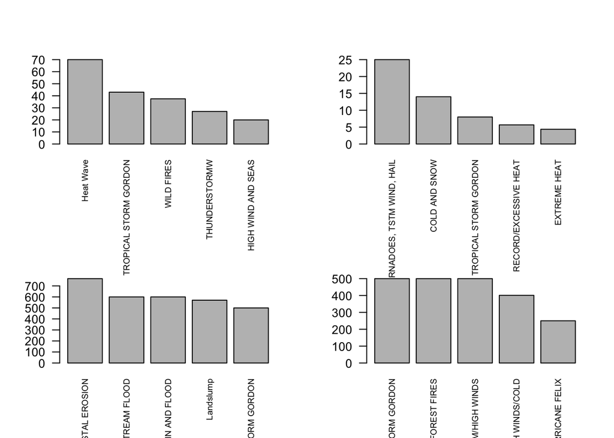

```r
par(mfrow=c(2,2))
with(injuries, barplot(INJURIES, names.arg=EVTYPE, las=2, cex.names=.7))
with(fatalities, barplot(FATALITIES, names.arg=EVTYPE, las=2, cex.names=.7))
with(propdmg, barplot(PROPDMG, names.arg=EVTYPE, las=2, cex.names=.7))
with(cropdmg, barplot(CROPDMG, names.arg=EVTYPE, las=2, cex.names=.7))
```

The top five events for all four type of harm are

```r
injuries
```

```
##                    EVTYPE INJURIES
## 277             Heat Wave     70.0
## 851 TROPICAL STORM GORDON     43.0
## 954            WILD FIRES     37.5
## 821         THUNDERSTORMW     27.0
## 366    HIGH WIND AND SEAS     20.0
```

```r
fatalities
```

```
##                         EVTYPE FATALITIES
## 842 TORNADOES, TSTM WIND, HAIL     25.000
## 72               COLD AND SNOW     14.000
## 851      TROPICAL STORM GORDON      8.000
## 580      RECORD/EXCESSIVE HEAT      5.667
## 142               EXTREME HEAT      4.364
```

```r
propdmg
```

```
##                     EVTYPE PROPDMG
## 52         COASTAL EROSION     766
## 589 RIVER AND STREAM FLOOD     600
## 291   HEAVY RAIN AND FLOOD     600
## 445              Landslump     570
## 851  TROPICAL STORM GORDON     500
```

```r
cropdmg
```

```
##                    EVTYPE CROPDMG
## 851 TROPICAL STORM GORDON     500
## 190          FOREST FIRES     500
## 118 DUST STORM/HIGH WINDS     500
## 392       HIGH WINDS/COLD     401
## 406       HURRICANE FELIX     250
```